# R Introduction (STAT 420)

## R Resources

You should install R http://cran.r-project.org/ and I also recommend RStudio http://www.rstudio.com/ which makes thing a lot easier. Sometimes I use Notepad++ in combination with NppToR when I don’t really need all that fancy interface.

## Basic calculations

Most of the calculations are self-explanatory, I will not go over them.

```r
sin(pi*(exp(log(5)) + 0.5))
```

```
## [1] -1
```

## Getting help

You can put a question mark in front of the function name and RStudio will display the documentation. Your best friend is google.

```r
?cbind
```

## Installing packages

Packages are like add-ons that can do special modeling or calculation tasks. You need to install them first using `install.packages()`. To use functions defined in the package, you need to load them using `library()`. The package `glmnet` is developed to fit penalzied linear models such as Lasso and ElasticNet.

```r
install.packages("glmnet")
library(glmnet)
```

## R dataset

Packages may also include datasets, the family height dataset collected by Francis Galton (1886) is provided in the `HistData` package.

```r
data(GaltonFamilies, package = "HistData")
head(GaltonFamilies)
```

```
##   family father mother midparentHeight children childNum gender childHeight
## 1    001   78.5   67.0           75.43        4        1   male        73.2
## 2    001   78.5   67.0           75.43        4        2 female        69.2
## 3    001   78.5   67.0           75.43        4        3 female        69.0
## 4    001   78.5   67.0           75.43        4        4 female        69.0
## 5    002   75.5   66.5           73.66        4        1   male        73.5
## 6    002   75.5   66.5           73.66        4        2   male        72.5
```

`Data Frames` are often used to store a dataset. Other datatypes include `Vectors`, `Matrices`, `Arrays`, `Lists`, and `Factors`. Before performing calculations on a data set, you should always check the data type

```r
class(GaltonFamilies)
```

```
## [1] "data.frame"
```

```r
str(GaltonFamilies)
```

```
## 'data.frame':    934 obs. of  8 variables:
##  $ family         : Factor w/ 205 levels "001","002","003",..: 1 1 1 1 2 2 2 2 3 3 ...
##  $ father         : num  78.5 78.5 78.5 78.5 75.5 75.5 75.5 75.5 75 75 ...
##  $ mother         : num  67 67 67 67 66.5 66.5 66.5 66.5 64 64 ...
##  $ midparentHeight: num  75.4 75.4 75.4 75.4 73.7 ...
##  $ children       : int  4 4 4 4 4 4 4 4 2 2 ...
##  $ childNum       : int  1 2 3 4 1 2 3 4 1 2 ...
##  $ gender         : Factor w/ 2 levels "female","male": 2 1 1 1 2 2 1 1 2 1 ...
##  $ childHeight    : num  73.2 69.2 69 69 73.5 72.5 65.5 65.5 71 68 ...
```

These objects contains atomic vectors of basic data types such as

- **Logical**: `TRUE` and `FALSE`
- **Numeric**: `12.3`, `5`, `666`
- **Integer**: `12L`, `0L`
- **Complex**: `1 + 2i`
- **Character**: `"Statistics"`, `"glhf"`, `"GG"`

A vector holds multiple elements

```r
members = c("Fathor", "Mother", "Child")
```

A matrix can be defined by

```r
M = matrix( c(1:6), nrow = 2, ncol = 3, byrow = TRUE)
M
```

```
##      [,1] [,2] [,3]
## [1,]    1    2    3
## [2,]    4    5    6
```

Arrays are multi-dimentional:

```r
A = array(c(1:24),dim = c(4,3,2))
A
```

```
## , , 1
##
##      [,1] [,2] [,3]
## [1,]    1    5    9
## [2,]    2    6   10
## [3,]    3    7   11
## [4,]    4    8   12
##
## , , 2
##
##      [,1] [,2] [,3]
## [1,]   13   17   21
## [2,]   14   18   22
## [3,]   15   19   23
## [4,]   16   20   24
```

Lists can be used to store different types of objects

```r
mylist = list(c(2,5,3), pi, sum)
mylist
```

```
## [[1]]
## [1] 2 5 3
##
## [[2]]
## [1] 3.141593
##
## [[3]]
## function (..., na.rm = FALSE)  .Primitive("sum")
```

Factors are acturaly stored as vectors, but has a distinct list of values as the labels for each element.

```r
courses = factor(c("STAT", "MATH", "MATH", "CS", "HIST", "CS"))
courses
```

```
## [1] STAT MATH MATH CS   HIST CS
## Levels: CS HIST MATH STAT
```

You can change their labels

```r
levels(courses) = c("A", "B", "C", "D")
courses
```

```
## [1] D C C A B A
## Levels: A B C D
```

## Descriptive Statistics

Descriptive Statistics are usually the first step in a data analysis

```r
x = GaltonFamilies$childHeight
mean(x)
```

```
## [1] 66.74593
```

```r
sum(x)/length(x)
```

```
## [1] 66.74593
```

```r
sd(x)
```

```
## [1] 3.579251
```

```r
sqrt(sum((x - mean(x))^2)/(length(x) - 1))
```

```
## [1] 3.579251
```

```r
c(mean(x) - qt(0.975, 933) * sd(x)/sqrt(934), mean(x) + qt(0.975, 933) * sd(x)/sqrt(934))
```

```
## [1] 66.51609 66.97577
```

```r
t.test(x, alternative = c("two.sided"), conf.level = 0.95)
```

```
##
##  One Sample t-test
##
## data:  x
## t = 569.91, df = 933, p-value < 2.2e-16
## alternative hypothesis: true mean is not equal to 0
## 95 percent confidence interval:
##  66.51609 66.97577
## sample estimates:
## mean of x
##  66.74593
```

A researcher claims that the mean child height at that time is at least 67. How to test this statement? What is the $p$-value associated with this test?

> $H_0$: $\mu \geq 67$ $\quad$ vs. $\quad$ $H_1$: $\mu < 67$

```r
t.test(x, mu = 67, alternative = "less", conf.level = 0.95)
```

```
##
##  One Sample t-test
##
## data:  x
## t = -2.1694, df = 933, p-value = 0.01515
## alternative hypothesis: true mean is less than 67
## 95 percent confidence interval:
##      -Inf 66.93876
## sample estimates:
## mean of x
##  66.74593
```

## Including Plots

Plots are good ways for visualizing the data. Sometimes transformation is requried if the distribution is in wired shape. Histogram shows the empirical distribution, and box plot can be used to compare distributions and detect outliers.

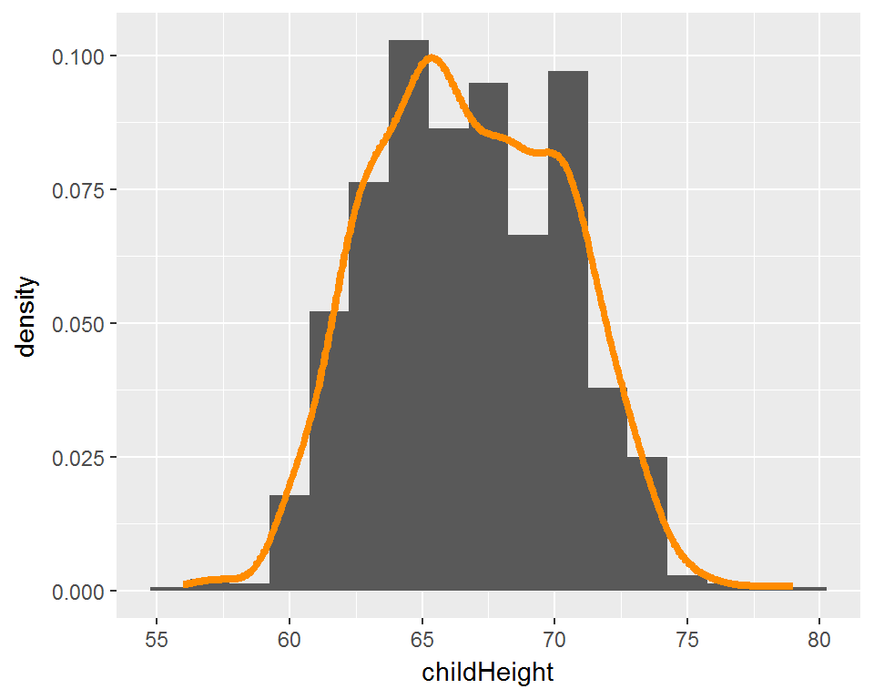

```r
library(ggplot2)
ggplot(GaltonFamilies, aes(x = childHeight)) + geom_histogram(aes(y = ..density..), binwidth = 1.5) + geom_line(stat="density", lwd = 1.5, col = "darkorange")
```

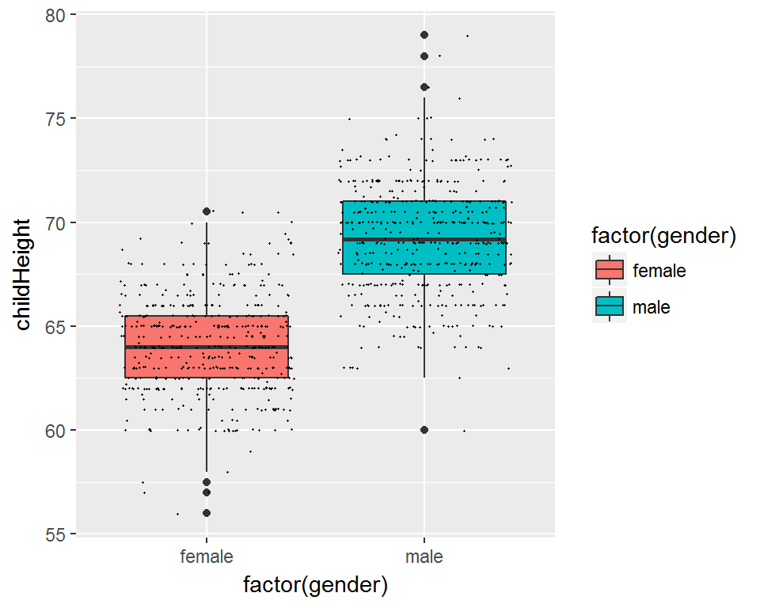

```r
ggplot(GaltonFamilies, aes(factor(gender), childHeight)) + geom_boxplot(aes(fill = factor(gender))) + geom_jitter(cex = 0.25)
```

3D plots help to explore higher level of relationships and interations.

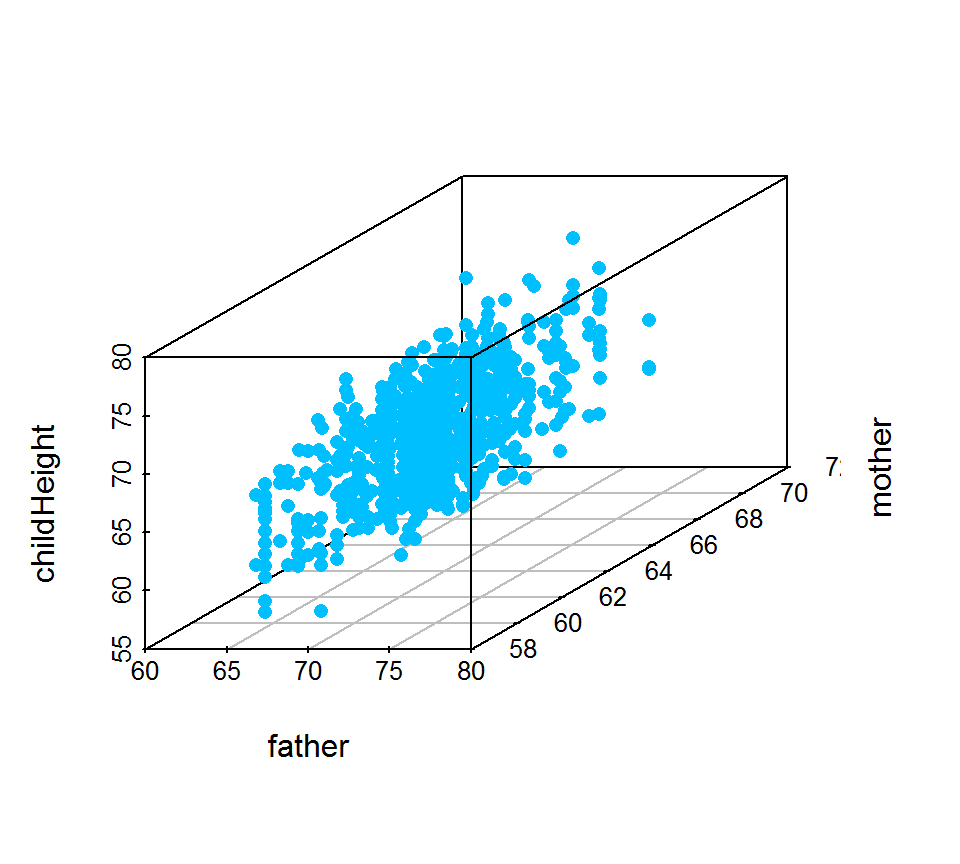

```r
library(scatterplot3d)
scatterplot3d(GaltonFamilies[, c(2,3,8)], pch = 16, color="deepskyblue")
```

## Using R as a simulation tool

Simulation can used for many different goals. For example, we want to know the 90% quantile of a mixed distribution (with 0.5 probabiliy being `standard normal` and 0.5 probability being `t(1)`). Since we do now know how to calculate that theoritically, we can simulate enough data to approximate that value. To generate the data,

```r
n = 1e6
x = ifelse(rbinom(n, 1, 0.5), rnorm(n), rt(n, 1))
```

```r
summary(x)
```

[output not shown]

```r
quantile(x, probs = 0.9)
```

[output not shown]

Let’s use a simulation study to “validate” the central limit theorem. Genereate 1000 datasets of size 2. Each observation follows an independent exponential(1) distribution. Calculate and plot the mean of each dataset. Repeat this with size 100 in each dataset, and compare the histogram.

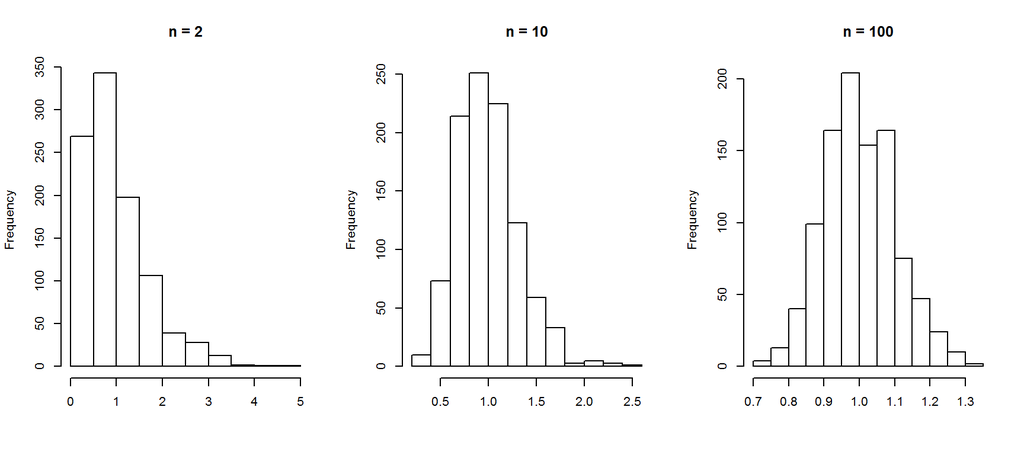

```r
par(mfrow=c(1,3))
X2 = matrix(rexp(2000), 1000, 2)
X10 = matrix(rexp(100000), 1000, 10)
X100 = matrix(rexp(500000), 1000, 100)
hist(apply(X2, 1, mean), main = "n = 2", xlab = "")
hist(apply(X10, 1, mean), main = "n = 10", xlab = "")
hist(apply(X100, 1, mean), main = "n = 100", xlab = "")
```

## Parallel computing

There are easy ways to utilize multiple cores if you have a large number of simulation runs. For example, we want to know the distribution of an OLS estimator:

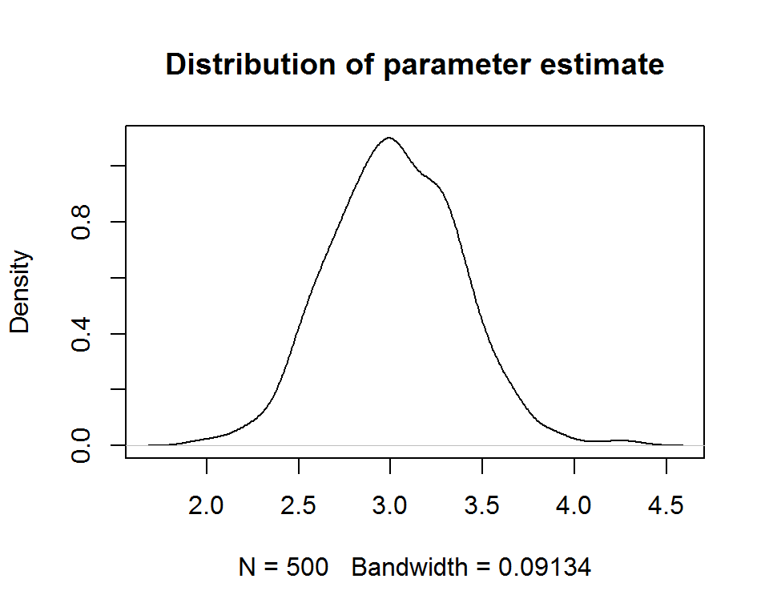

```r
library(doParallel)
library(foreach)
library(parallel)
registerDoParallel(cores=4) # if you do have at least 4 cores
# getDoParWorkers()
n = 100 # each dataset contains 100 observations
betahat <- foreach(i=1:500, .combine="c") %dopar% # 500 simualtions are performed
  {
    x = runif(n)
    y = 3*x + rnorm(n)
    lm(y ~ x)$coef[2] # extract the parameter estimate of the slope
  }
plot(density(betahat), main = "Distribution of parameter estimate")
```

## R Markdown

This document is created using R Markdown, the source file and html file are posted on the course website.